# Covid -19 Analysis in Norway

Umesh Liyanage

# **1.Introduction**

Norway is a country in Northern Europe occupying the western portion of the Scandinavian Peninsula as well as the volcanic island Jan Mayen and the Arctic archipelago of Svalbard. Norway borders the North Sea, the North Atlantic Ocean, Finland, Sweden, and Russia. The geography of Norway is rugged with steep fjords and mountains. The government system is a parliamentary constitutional monarchy; the chief of state is the king, and the head of government is the prime minister. Norway has a mixed economic system with a combination of free-market activity and government intervention. Norway is a member of the European Free Trade Association (EFTA). Norway has a total area of 385,207 square kilometres (148,729 sq mi) and had a population of 5,385,300 in November 2020. The country shares a long eastern border with Sweden (1,619 km or 1,006 mi long). Norway is bordered by Finland and Russia to the north-east and the Skagerrak strait to the south, with Denmark on the other side. Norway has an extensive coastline, facing the North Atlantic Ocean and the Barents Sea. The maritime influence dominates Norway’s climate with mild lowland temperatures on the sea coasts, whereas the interior, while colder, is also a lot milder than areas elsewhere in the world on such northerly latitudes. Even during polar night in the north, temperatures above freezing are commonplace on the coastline. The maritime influence brings high rainfall and snowfall to some areas of the country.

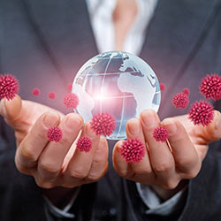

### • Visualization of the location

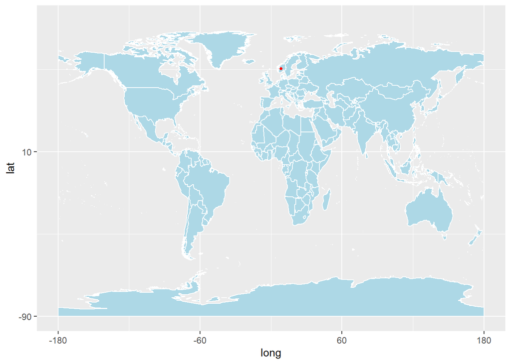

### • Climate condition

Norway is a popular tourist destination year-round, thanks to its gorgeous green fjords in the summer and the northern lights in the winter. The weather in Norway is warmer than might be expected considering how far north it is. This is due to the warmth of the Gulf Stream, which results in a temperate climate for much of the country. This Scandinavian country has a climate that easily fluctuates from year to year, especially in its most northern parts, which are located at the edge of the global temperate zone. In the northern areas, summer temperatures can reach above 80 degrees Fahrenheit (27 degrees Celsius), while winters are dark and have more snow than other parts of the country. In the coastal and inland regions, the climate varies considerably. The coastal areas have a climate with cooler summers. Winters are relatively moderate and rainy with little snow or frost. Inland areas (like Oslo) have a continental climate with colder winters (think minus 13 degrees Fahrenheit, or 25 below zero Celsius) but warmer summers. Weather in Norway is best between May and September when it’s usually mild and clear.

### • Lock-down Status of the country

20/08/2021: The Norwegian Government has decided to introduce entry restrictions and quarantine requirements for several areas in the Nordic region, two countries in Europe, and some third countries. This decision is based on an updated assessment of the infection rate by the Norwegian Institute of Public Health, and is intended to reduce the risk of imported cases of COVID-19. All of the changes will enter into effect on Monday 23 August at 12 am.

### • Actions taken by country

Avoid shaking hands and hugging people you do not live with. Cough or sneeze into a paper tissue or the crook of your elbow. Work from home Home working should be used if possible Public transport Use of public transport should be avoided Domestic travel Limit leisure travel in Norway Health institutions No visits to members of vulnerable groups Mandated by law with potential sanctions Stay at Home People with respiratory tract infection symptoms must stay at home until at least 1 day after they feel completely well. Home Quarantine People who travelled abroad must quarantine in their home for 14 days from the day they returned to the country. Backdated to 27.02.2020. Exception for travel from Finland and Sweden. People who have been in close contact with someone with a confirmed case of COVID-19 must home quarantine for 14 days. Those in quarantine must remain at home and not attend school or work. They can go outside, carry out necessary shopping maintaining social distancing of at least 1 metre but not use public transport. People who live in the same household are not quarantined. Home isolation People with confirmed COVID-19 must be isolated at home or in a healthcare institution else. The isolation lasts until 3 days after you have recovered and at least 8 days after you became ill. They can go outside in private garden or balcony and should try to maintain social distance from others in their household; people in the same household are in quarantine. Closure Educational institutions (from Kindergarten to Higher Education) Exception: Open to children of key workers up to 10, and children with special needs Restaurants, bars, pubs and clubs. Exception: If they can serve food to customers maintaining social distancing of 1 metre. Fitness centres, swimming pools and waterparks. Hairdressers, tattoo and piercing parlours, massage studios, spas and beauty parlours. Cancelled/postponed All organised sports activities, competitions and cultural events. International travel ban Applies to healthcare professionals with patient contact.

## **2.Exploratory Data Analysis**

### • Visualization of death, confirmed, recovered, active cases

### Summary of data

```
      date              province           country               lat
 Min.   :2020-01-22   Length:1773        Length:1773        Min.   :60.47
 1st Qu.:2020-06-17   Class :character   Class :character   1st Qu.:60.47
 Median :2020-11-12   Mode  :character   Mode  :character   Median :60.47
 Mean   :2020-11-12                                         Mean   :60.47
 3rd Qu.:2021-04-09                                         3rd Qu.:60.47
 Max.   :2021-09-18                                         Max.   :60.47
      long           type               cases
 Min.   :8.469   Length:1773        Min.   :   0.0
 1st Qu.:8.469   Class :character   1st Qu.:   0.0
 Median :8.469   Mode  :character   Median :   0.0
 Mean   :8.469                      Mean   : 113.1
 3rd Qu.:8.469                      3rd Qu.:  57.0
 Max.   :8.469                      Max.   :7695.0
```

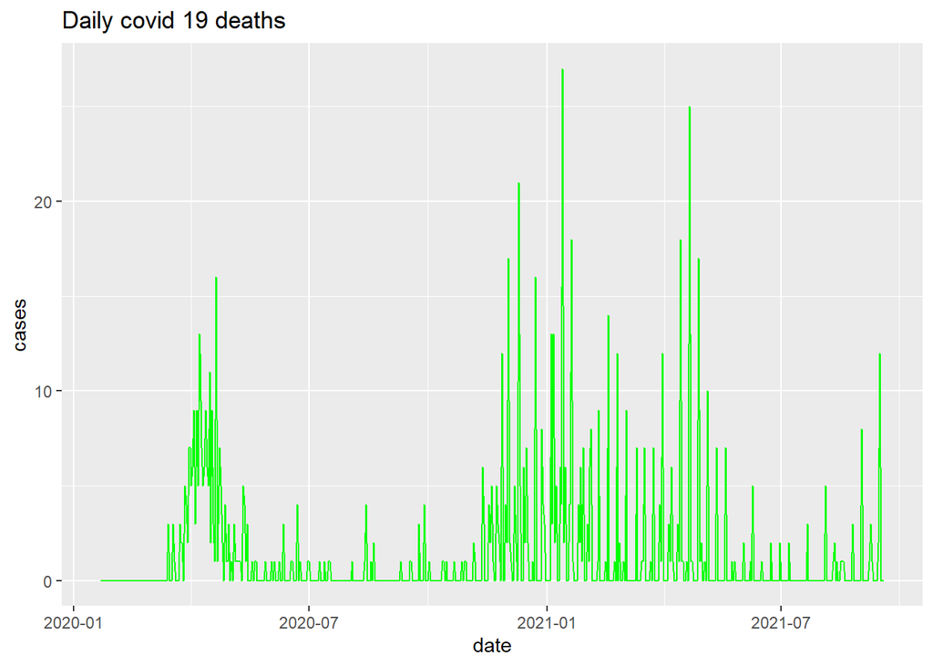

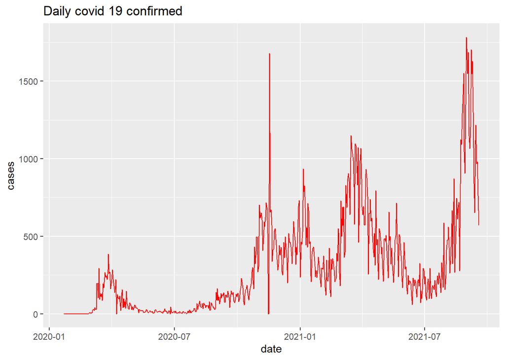

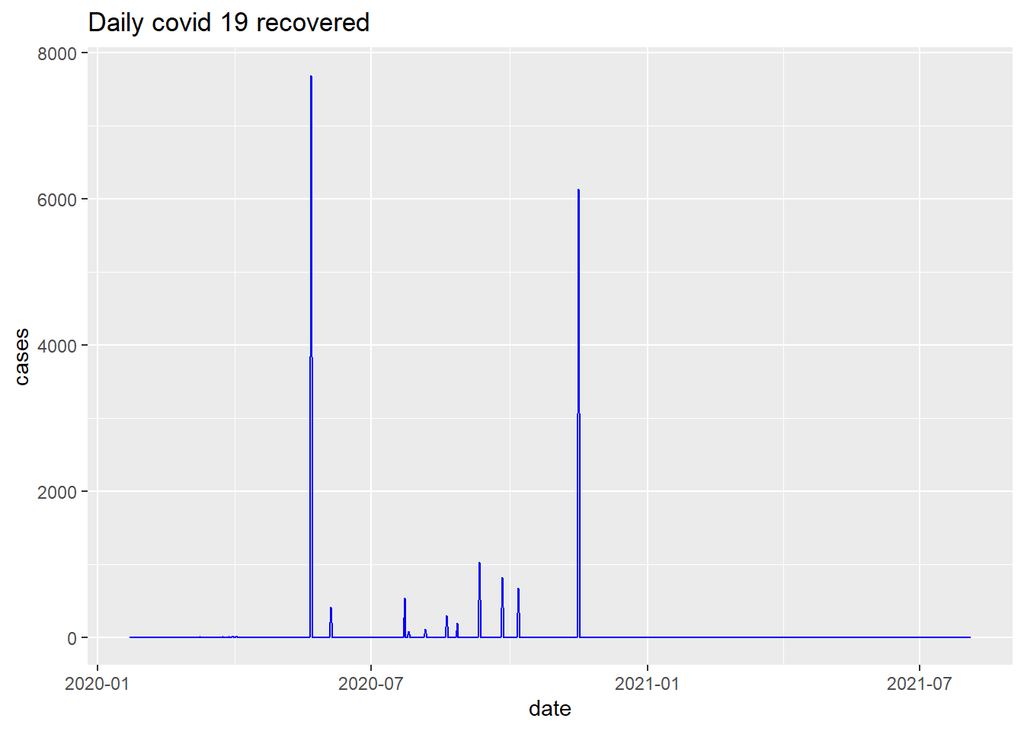

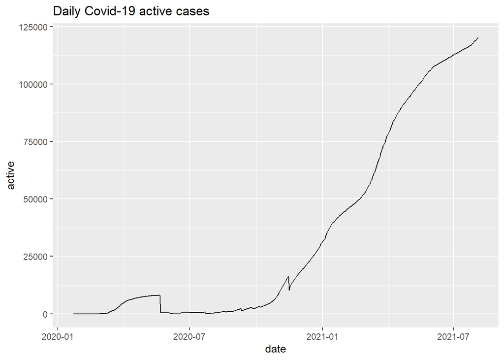

### • Comparison between the neighbouring countries

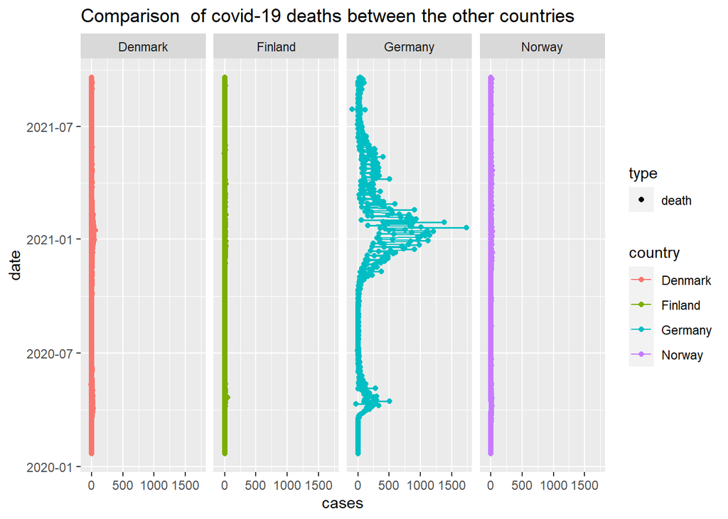

According to the plot , we can’t see a dangerous situation in norway than it’s neibhouring countries.. Specially when we consider these informations between Germany and Norway, there is a huge difference between those two countries…When we consider about population, Norwegian population is equal to other neibhouring countries like Denmark and Finland..So Covid 19 cases and number of deaths in Norway is way similar to those two neighbouring countries..There is no huge gap between these three countries although in January 2021 there is a huge improvement of covid 19 cases in Germany , we can’t see any considerable information about Norway.

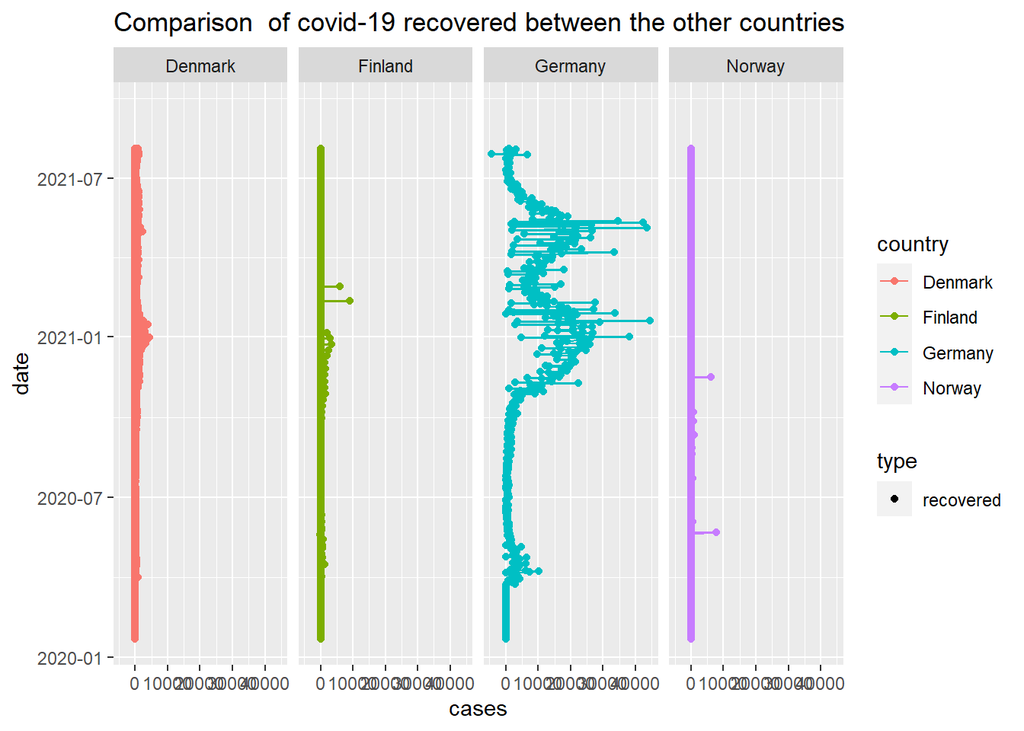

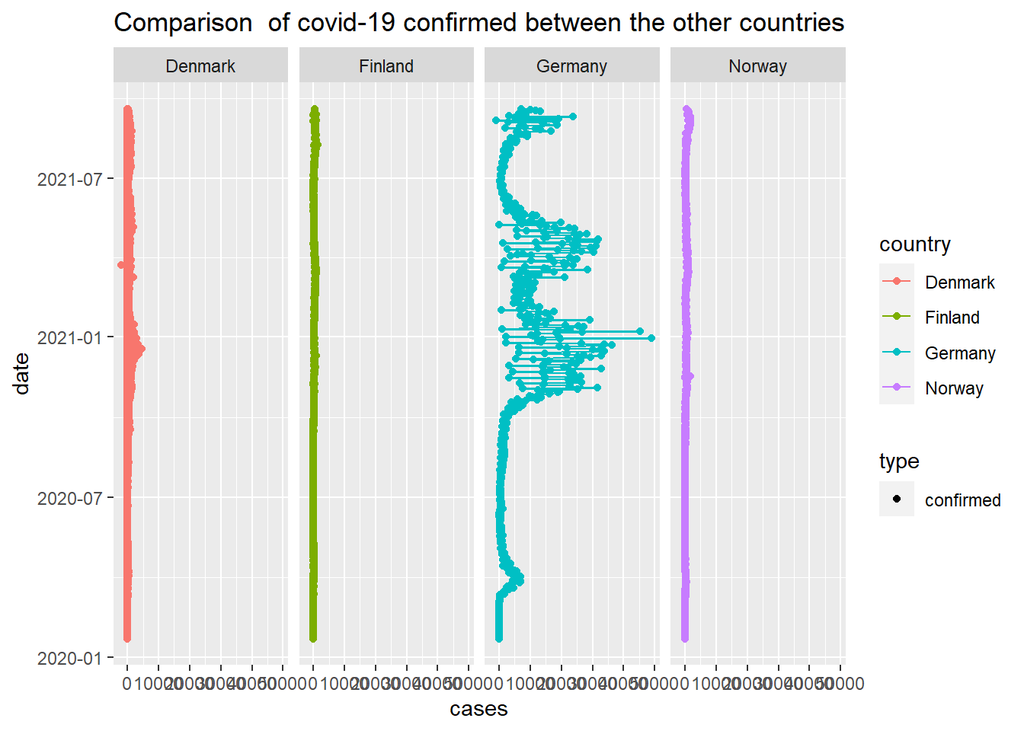

## **4.References**

• https://www.google.lk/url?sa=t&source=web&rct=j&url=https://globaledge.msu.edu/countries/norway&ved=2ahUKEwi-nNK4jJzzAhV-4nMBHW8ZBaIQFnoECAQQBQ&usg=AOvVaw0rc9vJFSlfupZxyP28cg-A

• https://www.google.lk/url?sa=t&source=web&rct=j&url=https://www.tripsavvy.com/weather-in-norway-4111770&ved=2ahUKEwjghJeujpzzAhUS5nMBHcLDCY0QFnoECCsQAQ&usg=AOvVaw35jUvQGkgMJTXQtS3NmVTp

• https://www.r-graph-gallery.com/279-plotting-time-series-with-ggplot2.html